# 16_Logistic_Regression

Kristopher Kyle

4/17/2019

## Predicting groups: Logistic Regression

Logistic regression is a method of predicting predefined group classification using one or more predictor variables. It is similar to DFA, but is more robust to violations of normality and the models are easier to interpret. Additionally, categorical variables can be used as predictors in logistic regression (but not in DFA)

#### Assumptions:

1. Multivariate normality (i.e., the predictor variables are normal for each group) - but logistic regression is robust to violations here
2. Homogeneity of variance
3. There must be at least as many cases as predictors. A more conservative case is to have approximately 15 cases per predictor.
4. If multiple predictor variables are used, variables must not be collinear.

### Data

In this tutorial, we will be looking at essays written by individuals at three different levels of lexical proficiency (Beginner, Intermediate, and High). We will also be looking at the average meaningfulness score for all words in each text. Meaningfulness scores are one way of determining how many concepts a particular word might be related to (e.g., the word “food” would be more “meaningful” than “zygote” because it could be used in more semantic contexts). We will be using meaningfulness scores to predict the lexical proficiency of each essay.

```r
library(dplyr)
mydata <- read.csv("data/anova_sample.csv", header = TRUE)
#my_data <- mydata %>% select(~ Proficiency, ~ Meaningfulness_AW, ~ L1_Word_Reaction_Time)
summary(mydata)
```

```
##    filenames     Proficiency  Frequent_Trigram_Proportion
##  1.txt  :  1   Beginner: 61   Min.   :0.0480
##  10.txt :  1   High    : 68   1st Qu.:0.1390
##  100.txt:  1   Int     :111   Median :0.1931
##  101.txt:  1                  Mean   :0.1930
##  102.txt:  1                  3rd Qu.:0.2427
##  103.txt:  1                  Max.   :0.3623
##  (Other):234
##  Meaningfulness_AW Register_Range_CW L1_Word_Reaction_Time Concreteness_AW
##  Min.   :325.4     Min.   :10.23     Min.   :594.3         Min.   :2.143
##  1st Qu.:363.7     1st Qu.:13.13     1st Qu.:610.5         1st Qu.:2.491
##  Median :375.4     Median :13.57     Median :615.9         Median :2.619
##  Mean   :376.1     Mean   :13.52     Mean   :616.4         Mean   :2.644
##  3rd Qu.:386.3     3rd Qu.:13.93     3rd Qu.:621.4         3rd Qu.:2.772
##  Max.   :453.7     Max.   :14.86     Max.   :655.6         Max.   :3.539
##
```

### Visualizing the data

First, we will take a look at density plots, which suggest that our data is roughly normal and has roughly equal variance.

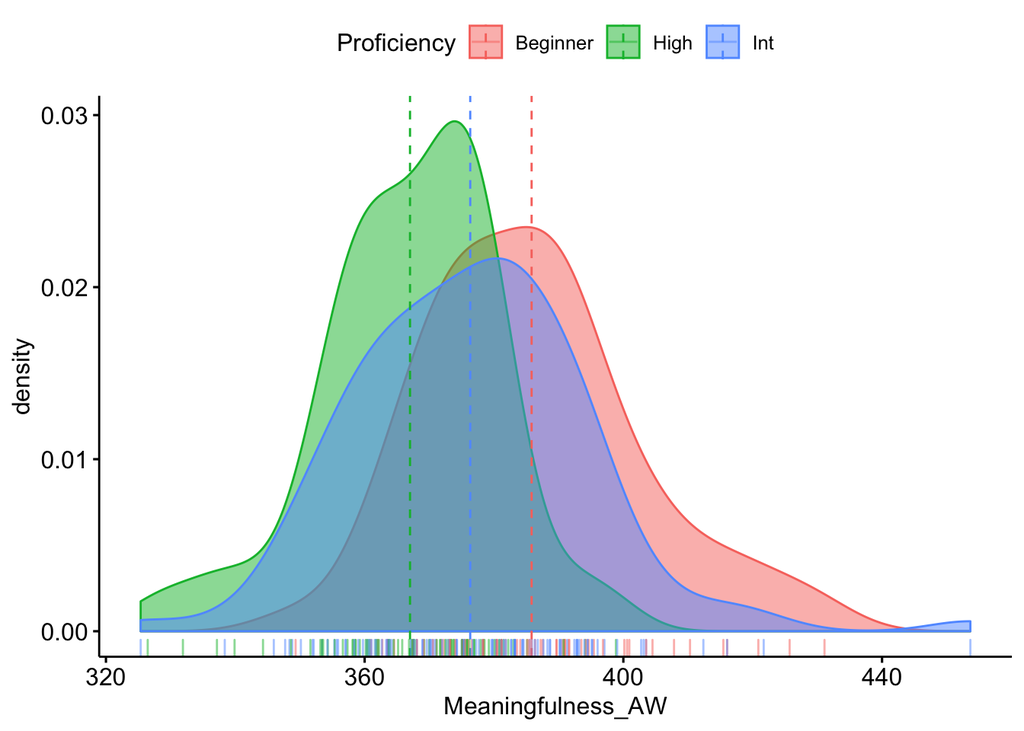

```r
library("ggpubr")
ggdensity(mydata, x = "Meaningfulness_AW",
          add = "mean", rug = TRUE,
          color = "Proficiency", fill = "Proficiency")
```

We will then look at boxplots, which suggest that the variance is roughly equal across groups and that the groups seem to be somewhat seperable based on meaningfulness scores. But, clearly there is going to be some classification error since there is overlap in our boxes.

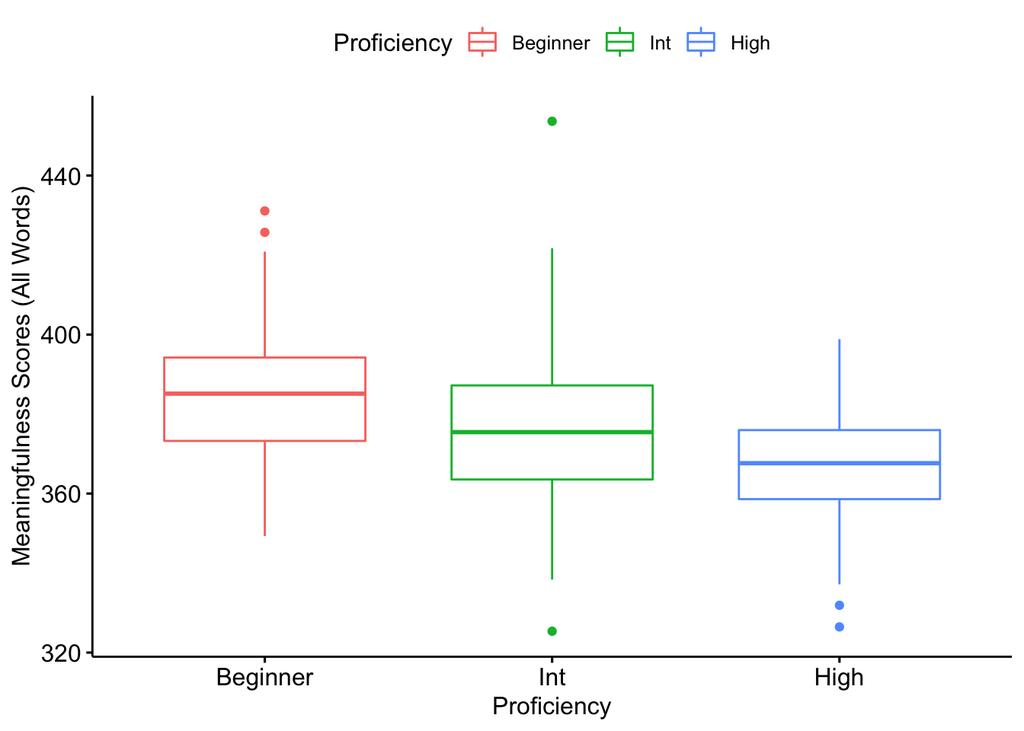

```r
ggboxplot(mydata, x = "Proficiency", y = "Meaningfulness_AW",
          color = "Proficiency",
          order = c("Beginner", "Int", "High"),
          ylab = "Meaningfulness Scores (All Words)", xlab = "Proficiency")
```

### Conducting the analysis

#### Training and test sets

To ensure the generalizability of our results, we will divide our data into a training set and a test set. The model will be created using the training set, and then will be applied to the test set in order to determine how well the model works on new data. A variety of splits can be used, but the most common is to use 67% of the data for the training set and 33% for the test set. In larger data sets, we might change that to a 90/10 split, and in a smaller data set, it might get changed to a 50/50 split. With an increase in training data, our model gets better. But, as our test set becomes smaller, it is less representative, and therefore might provide inaccurate results.

```r
library(MASS)
set.seed(1) #this will ensure that our random sample won't change each time we run the analysis
training_sample <- sample(c(TRUE, FALSE), nrow(mydata), replace = T, prob = c(0.67,0.33))
train <- mydata[training_sample, ] #this creates the training set
test <- mydata[!training_sample, ] #this creates the test set

summary(train)
```

```
##    filenames     Proficiency Frequent_Trigram_Proportion Meaningfulness_AW
##  1.txt  :  1   Beginner:40   Min.   :0.0480              Min.   :326.5
##  10.txt :  1   High    :39   1st Qu.:0.1372              1st Qu.:363.6
##  100.txt:  1   Int     :85   Median :0.1914              Median :375.8
##  102.txt:  1                 Mean   :0.1912              Mean   :376.7
##  105.txt:  1                 3rd Qu.:0.2330              3rd Qu.:386.3
##  106.txt:  1                 Max.   :0.3623              Max.   :453.7
##  (Other):158
##  Register_Range_CW L1_Word_Reaction_Time Concreteness_AW
##  Min.   :11.54     Min.   :595.1         Min.   :2.223
##  1st Qu.:13.14     1st Qu.:610.2         1st Qu.:2.512
##  Median :13.60     Median :616.7         Median :2.643
##  Mean   :13.54     Mean   :616.3         Mean   :2.659
##  3rd Qu.:13.91     3rd Qu.:621.3         3rd Qu.:2.782
##  Max.   :14.86     Max.   :641.8         Max.   :3.539
##
```

#### Building model

To build the logistic regression model, we will use the multinom() function in the nnet package.

```r
library(nnet)
#first, we set a reference level for our categorical data:
train$Proficiency <-relevel(train$Proficiency, ref = "Beginner")
#then, we build the model
lr1 <- multinom(Proficiency ~ Meaningfulness_AW , data = train)
summary(lr1)
```

```
## Call:
## multinom(formula = Proficiency ~ Meaningfulness_AW, data = train)
##
## Coefficients:
##      (Intercept) Meaningfulness_AW
## High    30.39833       -0.08113951
## Int     12.14724       -0.02985717
##
## Std. Errors:
##       (Intercept) Meaningfulness_AW
## High 1.772633e-06      0.0006573507
## Int  1.319143e-06      0.0005153214
##
## Residual Deviance: 305.9042
## AIC: 313.9042
```

```r
#to get p values, we have to do a little more work
#first, we convert our data to z values:
z_lr1 <- summary(lr1)$coefficients / summary(lr1)$standard.errors

#then, we get the two-tailed p-value
pnorm(abs(z_lr1), lower.tail=FALSE)*2
```

```
##      (Intercept) Meaningfulness_AW
## High           0                 0
## Int            0                 0
```

In this case, both our intercept and our predictor variable have a p-value that approaches 0

```r
#this will give the probability that each observation should belong to each class
predicted_train <- predict(lr1,train,"probs")

#this is how we obtain the predicted values
predicted_class_train <- predict(lr1,train)

#this is our confusion matrix
cf1 <- table(predicted_class_train,train$Proficiency)
print(cf1)
```

```
##
## predicted_class_train Beginner High Int
##              Beginner        6    0   4
##              High            0    7  11
##              Int            34   32  70
```

Now, we can check the prediction accuracy more formally:

```r
n = sum(cf1) #number of essays
diag1 = diag(cf1) # number of correctly classified instances per class
macro_acc = sum(diag1)/n #macro accuracy
print(macro_acc)
```

```
## [1] 0.5060976
```

As we can see, our macro average for the training set is similar (but slightly lower) to our macro results for the DFA model in the previous tutorial.

We will now run a full work up on the prediction accuracy. To save ourselves some time later, we will create a function (called “prediction_stats()”), which will give us the stats for our confusion matrix.

```r
#The below stats are needed to calculate precision, recall, and F1
prediction_stats <- function(table1) {
n = sum(table1) #number of essays
nc = nrow(table1) # number of classes
diag1 = diag(table1) # number of correctly classified instances per class
rowsums = apply(table1, 1, sum) # number of instances per class
colsums = apply(table1, 2, sum) # number of predictions per class
p = rowsums / n # distribution of instances over the actual classes
q = colsums / n # distribution of instances over the predicted classes

 precision = diag1 / colsums
 recall = diag1 / rowsums
 f1 = 2 * precision * recall / (precision + recall)

 return(data.frame(precision, recall, f1))
}

prediction_stats(cf1)
```

```
##          precision    recall        f1
## Beginner 0.1500000 0.6000000 0.2400000
## High     0.1794872 0.3888889 0.2456140
## Int      0.8235294 0.5147059 0.6334842
```

These results indicate that although the macro average was slightly lower than the DFA model in the previous tutorial, the logistic regression model is a bit better at predicting the High group (and slightly less at predicting the INT group).

Now we calculate the effect size, which shows a very small effect (but one that is slightly larger than in the DFA model.

```r
library(psych)
cohen.kappa(cf1)
```

```
## Call: cohen.kappa1(x = x, w = w, n.obs = n.obs, alpha = alpha, levels = levels)
##
## Cohen Kappa and Weighted Kappa correlation coefficients and confidence boundaries
##                   lower estimate upper
## unweighted kappa -0.044    0.067  0.18
## weighted kappa   -0.299    0.034  0.37
##
##  Number of subjects = 164
```

#### Applying the model to the test set

Now we will apply the model to the test set and conduct our accuracy analysis.

```r
#this will give the probability that each observation should belong to each class
predicted_test <- predict(lr1,test,"probs")

#this is how we obtain the predicted values
predicted_class_test <- predict(lr1,test)

#this is our confusion matrix
cf2 <- table(predicted_class_test,test$Proficiency)
print(cf2)
```

```
##
## predicted_class_test Beginner High Int
##             Beginner        1    0   0
##             High            1    5   3
##             Int            19   24  23
```

With the table, we can get the macro average, micro accuracy results, and the effect size:

```r
sum(diag(cf2))/sum(cf2) #macro accuracy
```

```
## [1] 0.3815789
```

```r
prediction_stats(cf2)
```

```
##           precision    recall         f1
## Beginner 0.04761905 1.0000000 0.09090909
## High     0.17241379 0.5555556 0.26315789
## Int      0.88461538 0.3484848 0.50000000
```

```r
cohen.kappa(cf2)
```

```
## Call: cohen.kappa1(x = x, w = w, n.obs = n.obs, alpha = alpha, levels = levels)
##
## Cohen Kappa and Weighted Kappa correlation coefficients and confidence boundaries
##                   lower estimate upper
## unweighted kappa -0.055    0.055  0.16
## weighted kappa   -0.272    0.014  0.30
##
##  Number of subjects = 76
```

Clearly, these results are not great. What can we do to improve our model accuracy? Two options are to a) add more predictor variables and/or b) find better predictor variables. We will do this below.

### Using more than one predictor variable in a logistic regression.

In order to increase the prediction accuracy of our model, we are going to add another predictor variable (L1_Word_Reaction_Time). First, we need to check the assumptions for that variable AND ensure that it isn’t collinear with Meaningfulness_AW.

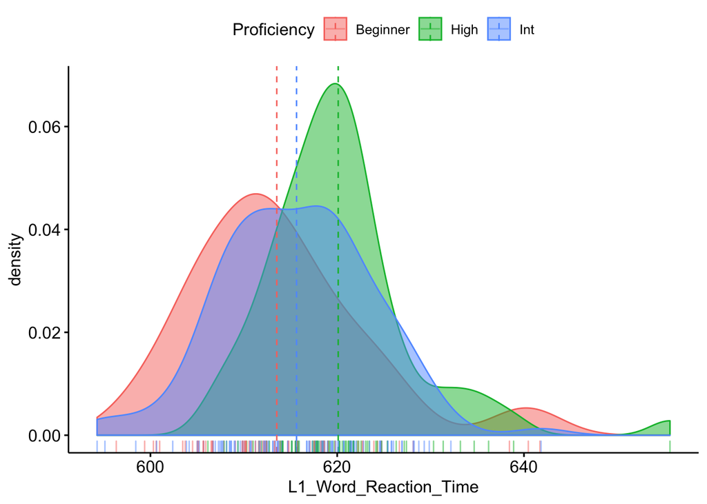

```r
library("ggpubr")
ggdensity(mydata, x = "L1_Word_Reaction_Time",
          add = "mean", rug = TRUE,
          color = "Proficiency", fill = "Proficiency")
```

The density plot suggest that the data is roughly normal and have roughly equal variance (though clearly the high group has somewhat less variance than the other two groups). At any rate, for this tutorial, we will proceed with the analysis.

Next, we check to determine whether our two predictor variables are collinear. They do not reach a threshold of r = .700 (a fairly conservative threshold), so we can use both variables in the same model.

```r
cor(mydata$Meaningfulness_AW,mydata$L1_Word_Reaction_Time)
```

```
## [1] -0.447012
```

Now, we build the model using both predictor variables and get the p-values

```r
#then, we build the model
lr2 <- multinom(Proficiency ~ Meaningfulness_AW + L1_Word_Reaction_Time , data = train)
summary(lr2)
```

```
## Call:
## multinom(formula = Proficiency ~ Meaningfulness_AW + L1_Word_Reaction_Time,
##     data = train)
##
## Coefficients:
##      (Intercept) Meaningfulness_AW L1_Word_Reaction_Time
## High  -6.2008375       -0.07155560            0.05351267
## Int   -0.1211151       -0.02702071            0.01820478
##
## Std. Errors:
##       (Intercept) Meaningfulness_AW L1_Word_Reaction_Time
## High 5.375382e-06        0.01492341           0.009044477
## Int  5.826800e-06        0.01000345           0.006239517
##
## Residual Deviance: 302.8007
## AIC: 314.8007
```

```r
#to get p values, we have to do a little more work
#first, we convert our data to z values:
z_lr2 <- summary(lr2)$coefficients / summary(lr2)$standard.errors
#then, we get the two-tailed p-value
pnorm(abs(z_lr2), lower.tail=FALSE)*2
```

```
##      (Intercept) Meaningfulness_AW L1_Word_Reaction_Time
## High           0      1.627918e-06          3.286379e-09
## Int            0      6.910251e-03          3.526701e-03
```

We see that our variables significantly contribute to the prediction of each class.

Now, we will construct our confusion matrix:

```r
#this will give the probability that each observation should belong to each class
predicted_train2 <- predict(lr2,train,"probs")

#this is how we obtain the predicted values
predicted_class_train2 <- predict(lr2,train)

#this is our confusion matrix
cf3 <- table(predicted_class_train2,train$Proficiency)
print(cf3)
```

```
##
## predicted_class_train2 Beginner High Int
##               Beginner        5    0   6
##               High            2    9   9
##               Int            33   30  70
```

And we can check our accuracy figures:

```r
sum(diag(cf3))/sum(cf3) #macro accuracy
```

```
## [1] 0.5121951
```

```r
prediction_stats(cf3)
```

```
##          precision    recall        f1
## Beginner 0.1250000 0.4545455 0.1960784
## High     0.2307692 0.4500000 0.3050847
## Int      0.8235294 0.5263158 0.6422018
```

```r
cohen.kappa(cf3)
```

```
## Call: cohen.kappa1(x = x, w = w, n.obs = n.obs, alpha = alpha, levels = levels)
##
## Cohen Kappa and Weighted Kappa correlation coefficients and confidence boundaries
##                   lower estimate upper
## unweighted kappa -0.024    0.087  0.20
## weighted kappa   -0.302    0.025  0.35
##
##  Number of subjects = 164
```

The results indicate that adding our predictor to the model increased the overall accuracy slightly.

#### Apply multivariate model to test set

Now, apply this model to the test set!

#### Next steps:

How might we go about model selection?